# Pokemon-Python

### Which Lengendary Pokemon has the highest skill?

```python
legendary = df[(df['LEGENDARY'] == True)]
print("Max Attack:",(legendary['ATTACK']).idxmax())
print("Max Special Attack:",(legendary['SP. ATK']).idxmax())
print("Max Special Defense:",(legendary['SP. DEF']).idxmax())
print("Max Speed:",(legendary['SPEED']).idxmax())
```

```
Max Attack: Mega Mewtwo X
Max Special Attack: Mega Mewtwo Y
Max Special Defense: Regice
Max Speed: DeoxysSpeed Forme
```

Which non-Lengendary Pokemon has the highest skill?

```python
nonlegendary = df[(df['LEGENDARY'] == False)]
print("Max Attack:",(nonlegendary['ATTACK']).idxmax())
print("Max Special Attack:",(nonlegendary['SP. ATK']).idxmax())
print("Max Special Defense:",(nonlegendary['SP. DEF']).idxmax())
print("Max Speed:",(nonlegendary['SPEED']).idxmax())
```

```
Max Attack: Mega Heracross
Max Special Attack: Mega Alakazam
Max Special Defense: Shuckle
Max Speed: Ninjask
```

```python
df.sort_values('TOTAL',ascending=False).head(3)
```

| NAME | TYPE 1 | TYPE 2 | TOTAL | HP | ATTACK | DEFENSE | SP. ATK | SP. DEF | SPEED | GENERATION | LEGENDARY |
| --- | --- | --- | --- | --- | --- | --- | --- | --- | --- | --- | --- |
| Mega Rayquaza | Dragon | Flying | 780 | 105 | 180 | 100 | 180 | 100 | 115 | 3 | True |
| Mega Mewtwo Y | Psychic | Psychic | 780 | 106 | 150 | 70 | 194 | 120 | 140 | 1 | True |
| Mega Mewtwo X | Psychic | Fighting | 780 | 106 | 190 | 100 | 154 | 100 | 130 | 1 | True |

### What is the distrubution of 'Attack'?

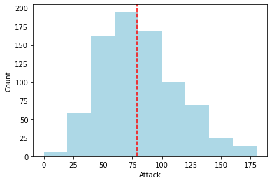

```python
bins=range(0,200,20) #they act as containers
plt.hist(df["ATTACK"],bins,histtype="bar",rwidth=1.2,color='lightblue') #hist() is used to plot a histogram
plt.xlabel('Attack') #set the xlabel name
plt.ylabel('Count') #set the ylabel name
plt.plot()
plt.axvline(df['ATTACK'].mean(),linestyle='dashed',color='red') #draw a vertical line showing the average Attack value
plt.show()
```

### What is the distrubution of 'Defense'?

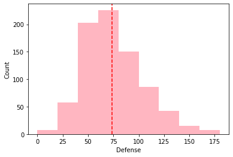

```python
bins=range(0,200,20) #they act as containers
plt.hist(df["DEFENSE"],bins,histtype="bar",rwidth=1.2,color='lightpink') #hist() is used to plot a histogram
plt.xlabel('Defense') #set the xlabel name
plt.ylabel('Count') #set the ylabel name
plt.plot()
plt.axvline(df['DEFENSE'].mean(),linestyle='dashed',color='red') #draw a vertical line showing the average Attack value
plt.show()
```

### What is the the relationship between Attack and Defense between Fire, Water, and Grass types?

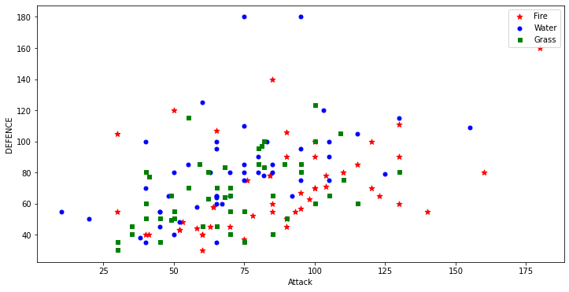

```python
fire=df[(df['TYPE 1']=='Fire') | ((df['TYPE 2'])=="Fire")] #fire contains all fire pokemons
water=df[(df['TYPE 1']=='Water') | ((df['TYPE 2'])=="Water")]  #all water pokemons
grass = df[(df['TYPE 1']=='Grass') | ((df['TYPE 2'])=="Grass")]  #all grass pokemons
plt.scatter(fire.ATTACK.head(50),fire.DEFENSE.head(50),color='Red',label='Fire',marker="*",s=50) #scatter plot
plt.scatter(water.ATTACK.head(50),water.DEFENSE.head(50),color='Blue',label="Water",s=25)
plt.scatter(grass.ATTACK.head(50),grass.DEFENSE.head(50),color='Green',label="Grass",marker=",",s=25)

plt.xlabel("Attack")
plt.ylabel("DEFENCE")
plt.legend()
plt.plot()
fig=plt.gcf()  #get the current figure using .gcf()
fig.set_size_inches(12,6) #set the size for the figure
plt.show()
```

### What are the strongest Pokemon for each type?

```python
strong = df.sort_values(by='TOTAL', ascending=False) #sorting the rows in descending order
strong = strong.drop_duplicates(subset=['TYPE 1'],keep='first')
strong['TYPE 1']
```

```
NAME
Mega Rayquaza              Dragon
Mega Mewtwo Y             Psychic
KyogrePrimal Kyogre         Water
GroudonPrimal Groudon      Ground
Arceus                     Normal
Mega Metagross              Steel
Mega Tyranitar               Rock
GiratinaOrigin Forme        Ghost
Ho-oh                        Fire
Xerneas                     Fairy
Yveltal                      Dark
Mega Sceptile               Grass
Mega Lucario             Fighting
Mega Ampharos            Electric
Mega Scizor                   Bug
Mega Glalie                   Ice
TornadusTherian Forme      Flying
Crobat                     Poison
Name: TYPE 1, dtype: object
```

### What are the weakest Pokemon for each type?

```python
weak = df.sort_values(by='TOTAL', ascending=True) #sorting the rows in descending order
weak = weak.drop_duplicates(subset=['TYPE 1'],keep='first')
weak['TYPE 1']
```

```
NAME
Sunkern          Grass
Azurill         Normal
Kricketot          Bug
Ralts          Psychic
Magikarp         Water
Pichu         Electric
Tyrogue       Fighting
Cleffa           Fairy
Poochyena         Dark
Zubat           Poison
Noibat          Flying
Swinub             Ice
Slugma            Fire
Diglett         Ground
Litwick          Ghost
Roggenrola        Rock
Beldum           Steel
Bagon           Dragon
Name: TYPE 1, dtype: object
```

### What is the distribution of skill for all Pokemon?

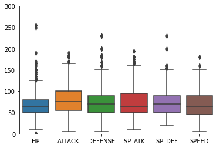

```python
df2=df.drop(['GENERATION','TOTAL', 'LEGENDARY'],axis=1)
sns.boxplot(data=df2)
plt.ylim(0,300)  #change the scale of y axix
plt.show()
```

### What is the distribution of attack for Pokemon by Type 1?

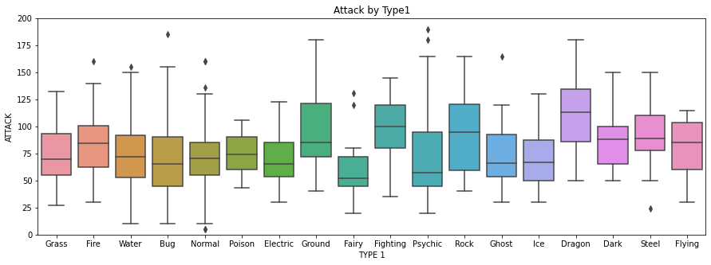

```python
plt.subplots(figsize = (15,5))
plt.title('Attack by Type1')
sns.boxplot(x = "TYPE 1", y = "ATTACK",data = df)
plt.ylim(0,200)
plt.show()
```

### What is the distribution of defense for Pokemon by Type 1?

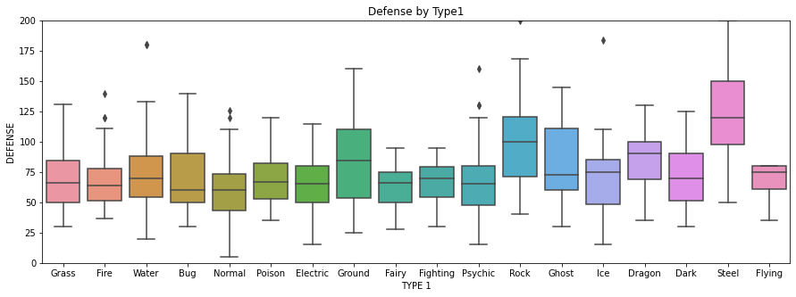

```python
plt.subplots(figsize = (15,5))
plt.title('Defense by Type1')
sns.boxplot(x = "TYPE 1", y = "DEFENSE",data = df)
plt.ylim(0,200)
plt.show()
```

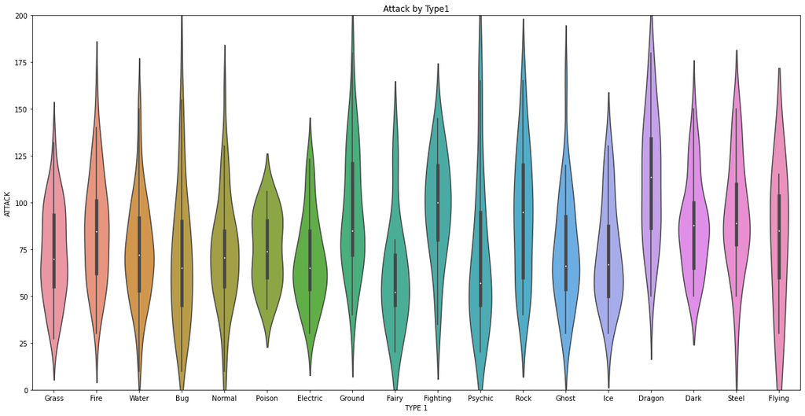

```python
plt.subplots(figsize = (20,10))
plt.title('Attack by Type1')
sns.violinplot(x = "TYPE 1", y = "ATTACK",data = df)
plt.ylim(0,200)
plt.show()
```

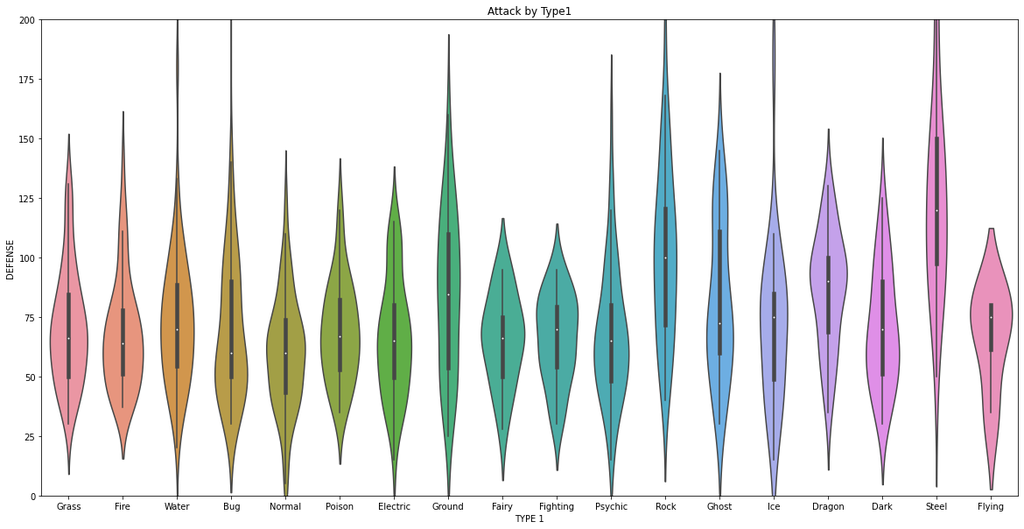

```python
plt.subplots(figsize = (20,10))
plt.title('Attack by Type1')
sns.violinplot(x = "TYPE 1", y = "DEFENSE",data = df)
plt.ylim(0,200)
plt.show()
```

### What is the strongest generation?

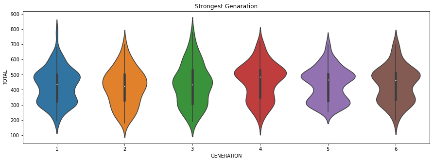

```python
plt.subplots(figsize = (15,5))
plt.title('Strongest Genaration')
sns.violinplot(x = "GENERATION", y = "TOTAL",data = df)
plt.show()
```

By the violin plots, we see generation 3 has the strongest Pokemon.

### Where do legendary Pokemon rank by total skill within their Type?

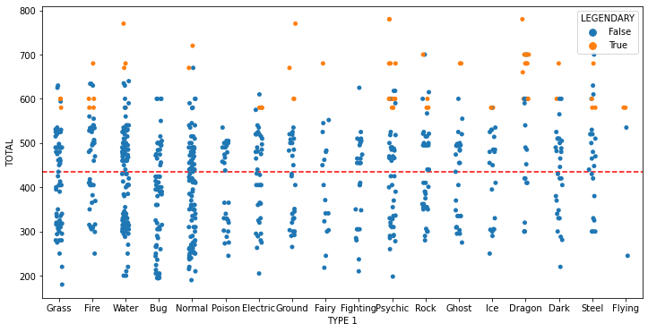

```python
plt.figure(figsize=(12,6))
top_types=df['TYPE 1'].value_counts()[:18] #take the top 10 Types
df1=df[df['TYPE 1'].isin(top_types.index)] #take the pokemons of the type with highest numbers, top 10
sns.stripplot(x='TYPE 1',y='TOTAL',data=df1,hue='LEGENDARY') # this plot shows the points belonging to individual pokemons
# It is distributed by Type
plt.axhline(df1['TOTAL'].mean(),color='red',linestyle='dashed')
plt.show()
```

Legendary pokemon often rank higher than all Pokemon by skill.

### Is there correlation between the variables?

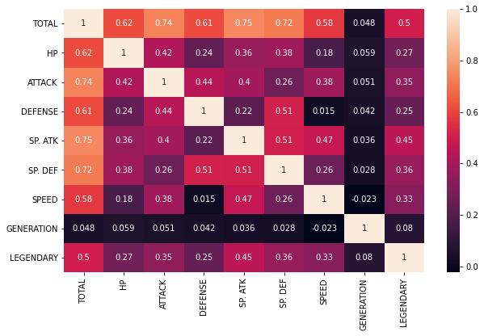

```python
plt.figure(figsize=(10,6)) #manage the size of the plot
sns.heatmap(df.corr(),annot=True) #df.corr() makes a correlation matrix and sns.heatmap is used to show the correlations heatmap
plt.show()
```

Not really, besides Total, which is a sum of the each of the skills, there does not appear to be a high correlation between any of the skills.

### What are the trends of type by Generation?

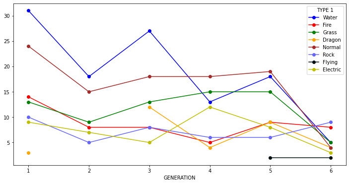

```python
a=df.groupby(['GENERATION','TYPE 1']).count().reset_index()
a=a[['GENERATION','TYPE 1','TOTAL']]
a=a.pivot('GENERATION','TYPE 1','TOTAL')
a[['Water','Fire','Grass','Dragon','Normal','Rock','Flying','Electric']].plot(color=['b','r','g','#FFA500','brown','#6666ff','#001012','y'],marker='o')
fig=plt.gcf()
fig.set_size_inches(12,6)
plt.show()
```

```python
### jupyter nbconvert Pokemon-Python.ipynb --to html --output index.html
```